# Lab_2_markdown

Zane Shango, Kurtis Potier, Nick Hiller

1/28/2020

## Read in Ames Data and Print Variable Names

```r
ameslist <- as.data.frame(read.csv("https://msudataanalytics.github.io/SSC442/Labs/data/ames.csv", header =TRUE,sep = ","))

names(ameslist)
```

```
##  [1] "Id"            "MSSubClass"    "MSZoning"      "LotFrontage"
##  [5] "LotArea"       "Street"        "Alley"         "LotShape"
##  [9] "LandContour"   "Utilities"     "LotConfig"     "LandSlope"
## [13] "Neighborhood"  "Condition1"    "Condition2"    "BldgType"
## [17] "HouseStyle"    "OverallQual"   "OverallCond"   "YearBuilt"
## [21] "YearRemodAdd"  "RoofStyle"     "RoofMatl"      "Exterior1st"
## [25] "Exterior2nd"   "MasVnrType"    "MasVnrArea"    "ExterQual"
## [29] "ExterCond"     "Foundation"    "BsmtQual"      "BsmtCond"
## [33] "BsmtExposure"  "BsmtFinType1"  "BsmtFinSF1"    "BsmtFinType2"
## [37] "BsmtFinSF2"    "BsmtUnfSF"     "TotalBsmtSF"   "Heating"
## [41] "HeatingQC"     "CentralAir"    "Electrical"    "X1stFlrSF"
## [45] "X2ndFlrSF"     "LowQualFinSF"  "GrLivArea"     "BsmtFullBath"
## [49] "BsmtHalfBath"  "FullBath"      "HalfBath"      "BedroomAbvGr"
## [53] "KitchenAbvGr"  "KitchenQual"   "TotRmsAbvGrd"  "Functional"
## [57] "Fireplaces"    "FireplaceQu"   "GarageType"    "GarageYrBlt"
## [61] "GarageFinish"  "GarageCars"    "GarageArea"    "GarageQual"
## [65] "GarageCond"    "PavedDrive"    "WoodDeckSF"    "OpenPorchSF"
## [69] "EnclosedPorch" "X3SsnPorch"    "ScreenPorch"   "PoolArea"
## [73] "PoolQC"        "Fence"         "MiscFeature"   "MiscVal"
## [77] "MoSold"        "YrSold"        "SaleType"      "SaleCondition"
## [81] "SalePrice"
```

## Questions Leading up to Exercise 1

Interpretations for confusing variables are: LotShape describes what the lot looks like, reg likely means rectangular and IR1, IR2, etc. are for irregular shapes MSSubClass is the type of dwelling in the sale according to googling it. The conditions do not provide enough information to say. It may be useful to check if they cause differnces in the sale price to see if they can be ignored. ameslist is of type list.

```r
typeof(ameslist)
```

```
## [1] "list"
```

## GarageTemp and Update ameslist to only 0 and 1 Values outputs

```r
library(rowr)

GarageTemp <- model.matrix( ~ GarageType - 1, data=ameslist )
ameslist <- cbind.fill(ameslist, GarageTemp)

ameslist$GarageOutside <- ifelse(ameslist$GarageTypeDetchd == 1 | ameslist$GarageTypeCarPort == 1, 1, 0)
unique(ameslist$GarageOutside)
```

```
## [1] 0 1
```

```r
# there are no NA values, just 0s and 1s
```

## Exercise 1

```r
Ames<-ameslist[which(sapply(ameslist,is.numeric)==TRUE)]

names(Ames)
```

```
##  [1] "Id"                "MSSubClass"        "LotFrontage"
##  [4] "LotArea"           "OverallQual"       "OverallCond"
##  [7] "YearBuilt"         "YearRemodAdd"      "MasVnrArea"
## [10] "BsmtFinSF1"        "BsmtFinSF2"        "BsmtUnfSF"
## [13] "TotalBsmtSF"       "X1stFlrSF"         "X2ndFlrSF"
## [16] "LowQualFinSF"      "GrLivArea"         "BsmtFullBath"
## [19] "BsmtHalfBath"      "FullBath"          "HalfBath"
## [22] "BedroomAbvGr"      "KitchenAbvGr"      "TotRmsAbvGrd"
## [25] "Fireplaces"        "GarageYrBlt"       "GarageCars"
## [28] "GarageArea"        "WoodDeckSF"        "OpenPorchSF"
## [31] "EnclosedPorch"     "X3SsnPorch"        "ScreenPorch"
## [34] "PoolArea"          "MiscVal"           "MoSold"
## [37] "YrSold"            "SalePrice"         "GarageType2Types"
## [40] "GarageTypeAttchd"  "GarageTypeBasment" "GarageTypeBuiltIn"
## [43] "GarageTypeCarPort" "GarageTypeDetchd"  "GarageOutside"
```

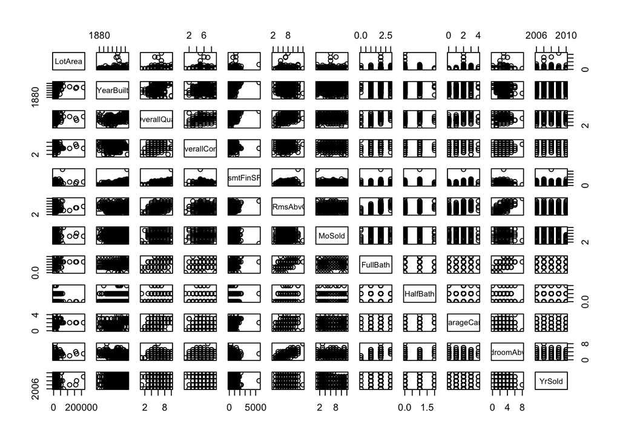

```r
pairs(~LotArea+YearBuilt+OverallQual+OverallCond+BsmtFinSF1+TotRmsAbvGrd+MoSold+FullBath+
        HalfBath+GarageCars+BedroomAbvGr+YrSold,data=Ames)
```

```r
Ames_small <- Ames[,c(4,5,6,7,10,20,21,22,24,27,36,37,38)]


head(Ames_small)
```

|  | LotArea | OverallQual | OverallCond | YearBuilt | BsmtFinSF1 | FullBath | HalfBath | BedroomAbvGr | TotRmsAbvGrd | GarageCars | MoSold | YrSold | SalePrice |
| --- | --- | --- | --- | --- | --- | --- | --- | --- | --- | --- | --- | --- | --- |
| 1 | 8450 | 7 | 5 | 2003 | 706 | 2 | 1 | 3 | 8 | 2 | 2 | 2008 | 208500 |
| 2 | 9600 | 6 | 8 | 1976 | 978 | 2 | 0 | 3 | 6 | 2 | 5 | 2007 | 181500 |
| 3 | 11250 | 7 | 5 | 2001 | 486 | 2 | 1 | 3 | 6 | 2 | 9 | 2008 | 223500 |
| 4 | 9550 | 7 | 5 | 1915 | 216 | 1 | 0 | 3 | 7 | 3 | 2 | 2006 | 140000 |
| 5 | 14260 | 8 | 5 | 2000 | 655 | 2 | 1 | 4 | 9 | 3 | 12 | 2008 | 250000 |
| 6 | 14115 | 5 | 5 | 1993 | 732 | 1 | 1 | 1 | 5 | 2 | 10 | 2009 | 143000 |

```r
cor(Ames_small)
```

```
##                   LotArea OverallQual  OverallCond   YearBuilt
## LotArea       1.000000000  0.10580574 -0.005636270  0.01422765
## OverallQual   0.105805742  1.00000000 -0.091932343  0.57232277
## OverallCond  -0.005636270 -0.09193234  1.000000000 -0.37598320
## YearBuilt     0.014227652  0.57232277 -0.375983196  1.00000000
## BsmtFinSF1    0.214103131  0.23966597 -0.046230856  0.24950320
## FullBath      0.126030627  0.55059971 -0.194149489  0.46827079
## HalfBath      0.014259469  0.27345810 -0.060769327  0.24265591
## BedroomAbvGr  0.119689908  0.10167636  0.012980060 -0.07065122
## TotRmsAbvGrd  0.190014778  0.42745234 -0.057583166  0.09558913
## GarageCars    0.154870740  0.60067072 -0.185757511  0.53785009
## MoSold        0.001204988  0.07081517 -0.003510839  0.01239847
## YrSold       -0.014261407 -0.02734671  0.043949746 -0.01361768
## SalePrice     0.263843354  0.79098160 -0.077855894  0.52289733
##                BsmtFinSF1    FullBath     HalfBath BedroomAbvGr
## LotArea       0.214103131  0.12603063  0.014259469   0.11968991
## OverallQual   0.239665966  0.55059971  0.273458099   0.10167636
## OverallCond  -0.046230856 -0.19414949 -0.060769327   0.01298006
## YearBuilt     0.249503197  0.46827079  0.242655910  -0.07065122
## BsmtFinSF1    1.000000000  0.05854314  0.004262424  -0.10735468
## FullBath      0.058543137  1.00000000  0.136380589   0.36325198
## HalfBath      0.004262424  0.13638059  1.000000000   0.22665148
## BedroomAbvGr -0.107354677  0.36325198  0.226651484   1.00000000
## TotRmsAbvGrd  0.044315624  0.55478425  0.343414858   0.67661994
## GarageCars    0.224053522  0.46967204  0.219178152   0.08610644
## MoSold       -0.015726948  0.05587213 -0.009049888   0.04654386
## YrSold        0.014358922 -0.01966884 -0.010268669  -0.03601389
## SalePrice     0.386419806  0.56066376  0.284107676   0.16821315
##              TotRmsAbvGrd  GarageCars       MoSold      YrSold   SalePrice
## LotArea        0.19001478  0.15487074  0.001204988 -0.01426141  0.26384335
## OverallQual    0.42745234  0.60067072  0.070815172 -0.02734671  0.79098160
## OverallCond   -0.05758317 -0.18575751 -0.003510839  0.04394975 -0.07785589
## YearBuilt      0.09558913  0.53785009  0.012398471 -0.01361768  0.52289733
## BsmtFinSF1     0.04431562  0.22405352 -0.015726948  0.01435892  0.38641981
## FullBath       0.55478425  0.46967204  0.055872129 -0.01966884  0.56066376
## HalfBath       0.34341486  0.21917815 -0.009049888 -0.01026867  0.28410768
## BedroomAbvGr   0.67661994  0.08610644  0.046543860 -0.03601389  0.16821315
## TotRmsAbvGrd   1.00000000  0.36228857  0.036907077 -0.03451635  0.53372316
## GarageCars     0.36228857  1.00000000  0.040521730 -0.03911690  0.64040920
## MoSold         0.03690708  0.04052173  1.000000000 -0.14572141  0.04643225
## YrSold        -0.03451635 -0.03911690 -0.145721413  1.00000000 -0.02892259
## SalePrice      0.53372316  0.64040920  0.046432245 -0.02892259  1.00000000
```

Most matched prior beliefs, overall condition and sale price were negatively correlated, which was surprising

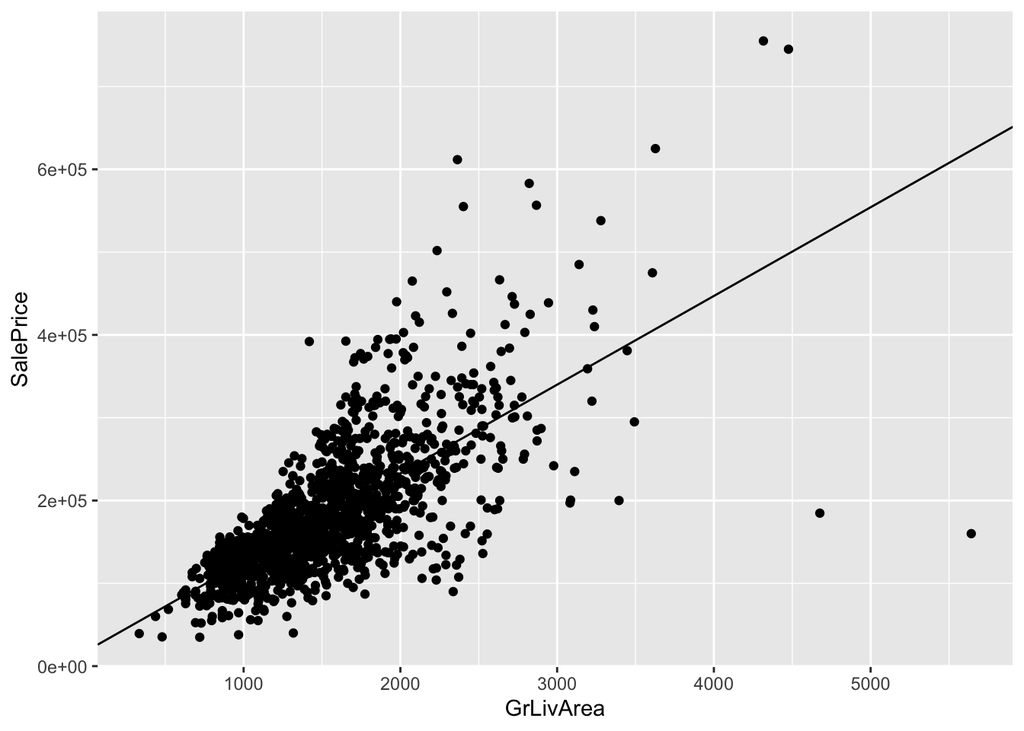

```r
library(ggplot2)

reg<-lm(SalePrice~GrLivArea,data=ameslist)
ggplot(ameslist,aes(x=GrLivArea,y=SalePrice))+
  geom_point()+
  geom_abline(intercept=coef(reg)["(Intercept)"],slope=coef(reg)["GrLivArea"])
```

```r
reg
```

```
##
## Call:
## lm(formula = SalePrice ~ GrLivArea, data = ameslist)
##
## Coefficients:
## (Intercept)    GrLivArea
##     18569.0        107.1
```

The following line gives information about the largest outlier above the line

```r
ameslist[which.max(ameslist$SalePrice-(ameslist$GrLivArea*coef(reg)["GrLivArea"]+coef(reg)["(Intercept)"])),]
```

|  | Id | MSSubClass | MSZoning | LotFrontage | LotArea | Street | Alley | LotShape | LandContour | Utilities | LotConfig | LandSlope | Neighborhood | Condition1 | Condition2 | BldgType | HouseStyle | OverallQual | OverallCond | YearBuilt | YearRemodAdd | RoofStyle | RoofMatl | Exterior1st | Exterior2nd | MasVnrType | MasVnrArea | ExterQual | ExterCond | … |
| --- | --- | --- | --- | --- | --- | --- | --- | --- | --- | --- | --- | --- | --- | --- | --- | --- | --- | --- | --- | --- | --- | --- | --- | --- | --- | --- | --- | --- | --- | --- |
| 899 | 899 | 20 | RL | 100 | 12919 | Pave | NA | IR1 | Lvl | AllPub | Inside | Gtl | NridgHt | Norm | Norm | 1Fam | 1Story | 9 | 5 | 2009 | 2010 | Hip | CompShg | VinylSd | VinylSd | Stone | 760 | Ex | TA | … |

## Exercise 2

Linear Model

```r
attach(Ames)
lm.fit <- lm(SalePrice ~ GrLivArea)
lm.fit
```

```
##
## Call:
## lm(formula = SalePrice ~ GrLivArea)
##
## Coefficients:
## (Intercept)    GrLivArea
##     18569.0        107.1
```

If GrLivArea is Omitted? Check Correlation

```r
cor(ameslist$GrLivArea,Ames_small)
```

```
##        LotArea OverallQual OverallCond YearBuilt BsmtFinSF1  FullBath
## [1,] 0.2631162   0.5930074 -0.07968587 0.1990097  0.2081711 0.6300116
##       HalfBath BedroomAbvGr TotRmsAbvGrd GarageCars     MoSold      YrSold
## [1,] 0.4157716    0.5212695    0.8254894  0.4672474 0.05023968 -0.03652582
##      SalePrice
## [1,] 0.7086245
```

```r
lm.fit
```

```
##
## Call:
## lm(formula = SalePrice ~ GrLivArea)
##
## Coefficients:
## (Intercept)    GrLivArea
##     18569.0        107.1
```

```r
summary(lm.fit)
```

```
##
## Call:
## lm(formula = SalePrice ~ GrLivArea)
##
## Residuals:
##     Min      1Q  Median      3Q     Max
## -462999  -29800   -1124   21957  339832
##
## Coefficients:
##              Estimate Std. Error t value Pr(>|t|)
## (Intercept) 18569.026   4480.755   4.144 3.61e-05 ***
## GrLivArea     107.130      2.794  38.348  < 2e-16 ***
## ---
## Signif. codes:  0 '***' 0.001 '**' 0.01 '*' 0.05 '.' 0.1 ' ' 1
##
## Residual standard error: 56070 on 1458 degrees of freedom
## Multiple R-squared:  0.5021, Adjusted R-squared:  0.5018
## F-statistic:  1471 on 1 and 1458 DF,  p-value: < 2.2e-16
```

Plot: there are some outliers but the data seems to be fairly normally grouped

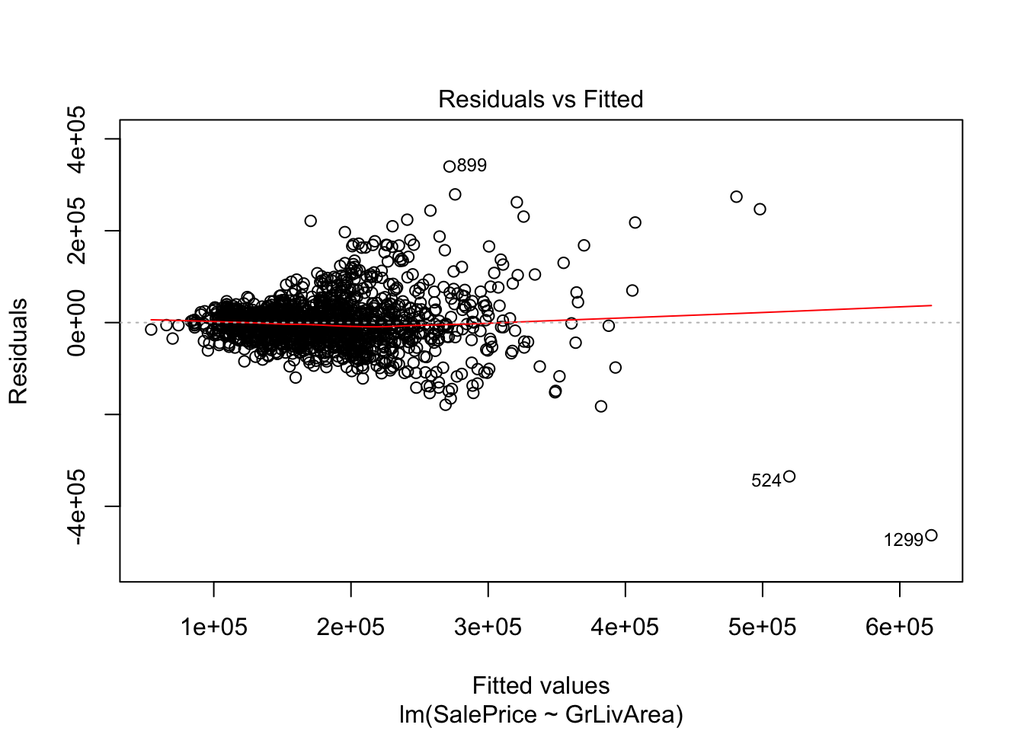

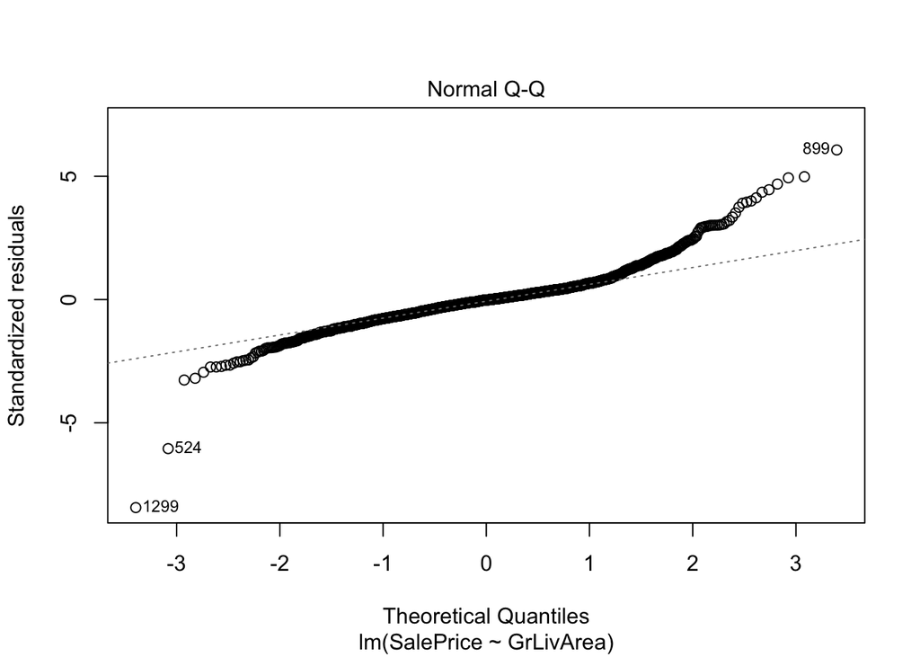

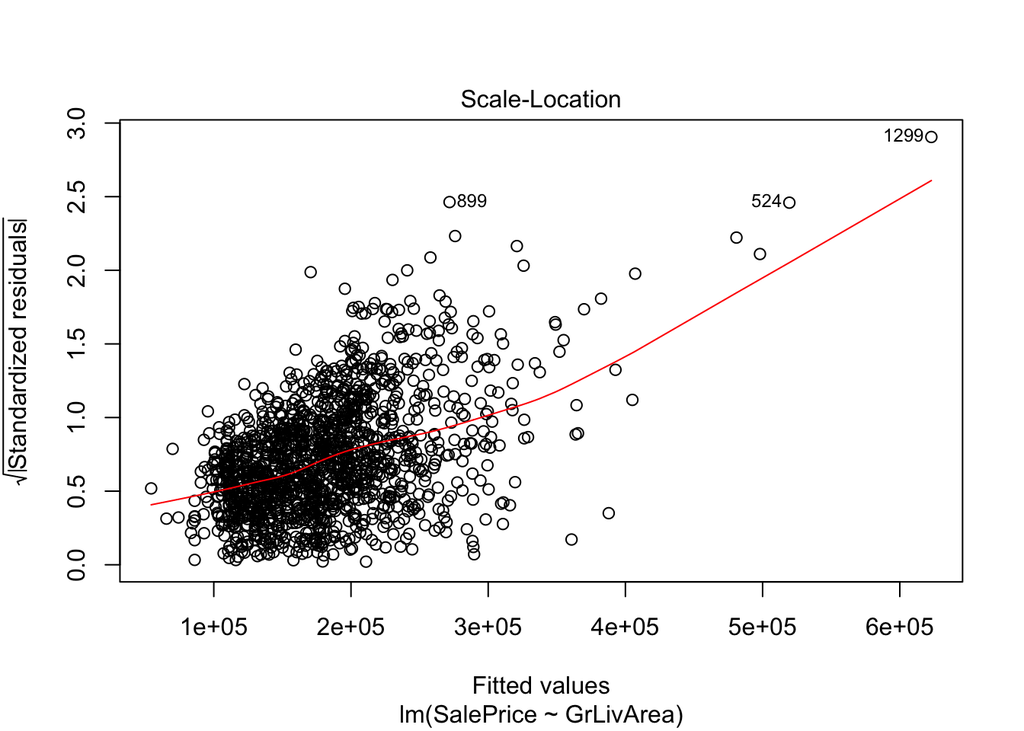

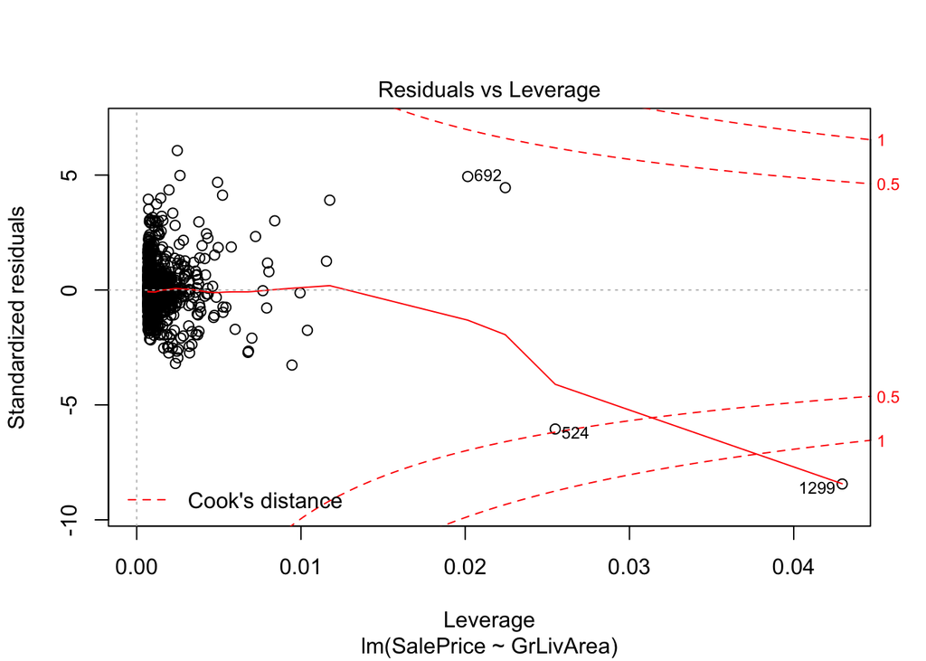

```r
plot(lm.fit)
```

Add LotArea to Model

```r
lm.fit = lm(SalePrice ~ GrLivArea + LotArea)
lm.fit
```

```
##
## Call:
## lm(formula = SalePrice ~ GrLivArea + LotArea)
##
## Coefficients:
## (Intercept)    GrLivArea      LotArea
##   1.662e+04    1.038e+02    6.618e-01
```

# Does controlling for LotArea change the qualitative conclusions from the previous regression?

Not very much, a greater ground living area still means greater sale price and is still very significant.

# What about the quantitative results?

The coefficient went from 107 to 104 on ground living area.

# Does the direction of the change in the quantitative results make sense to you?

Yes, adding lot area will reduce the coefficient since lotarea and grlivarea are related.

## Value of Indoor Garage

```r
summary(lm(SalePrice ~ GarageOutside,data=ameslist))
```

```
##
## Call:
## lm(formula = SalePrice ~ GarageOutside, data = ameslist)
##
## Residuals:
##     Min      1Q  Median      3Q     Max
## -145200  -50986  -18100   32389  572051
##
## Coefficients:
##               Estimate Std. Error t value Pr(>|t|)
## (Intercept)     180100       2465  73.059   <2e-16 ***
## GarageOutside     2849       4591   0.621    0.535
## ---
## Signif. codes:  0 '***' 0.001 '**' 0.01 '*' 0.05 '.' 0.1 ' ' 1
##
## Residual standard error: 79460 on 1458 degrees of freedom
## Multiple R-squared:  0.0002641,  Adjusted R-squared:  -0.0004216
## F-statistic: 0.3852 on 1 and 1458 DF,  p-value: 0.5349
```

## Multiple Linear Regression

```r
all<-lm(SalePrice~.,data=Ames)
summary(all)
```

```
##
## Call:
## lm(formula = SalePrice ~ ., data = Ames)
##
## Residuals:
##     Min      1Q  Median      3Q     Max
## -441034  -16641   -2397   14700  318576
##
## Coefficients: (4 not defined because of singularities)
##                     Estimate Std. Error t value Pr(>|t|)
## (Intercept)       -3.825e+05  1.707e+06  -0.224 0.822762
## Id                -1.294e+00  2.661e+00  -0.486 0.626961
## MSSubClass        -1.971e+02  3.464e+01  -5.690 1.63e-08 ***
## LotFrontage       -1.198e+02  6.132e+01  -1.954 0.050952 .
## LotArea            5.484e-01  1.576e-01   3.479 0.000522 ***
## OverallQual        1.866e+04  1.483e+03  12.579  < 2e-16 ***
## OverallCond        5.258e+03  1.369e+03   3.842 0.000129 ***
## YearBuilt          3.096e+02  8.786e+01   3.524 0.000443 ***
## YearRemodAdd       1.209e+02  8.676e+01   1.394 0.163608
## MasVnrArea         3.145e+01  7.033e+00   4.472 8.57e-06 ***
## BsmtFinSF1         1.709e+01  5.849e+00   2.923 0.003544 **
## BsmtFinSF2         8.187e+00  8.784e+00   0.932 0.351496
## BsmtUnfSF          4.924e+00  5.286e+00   0.931 0.351857
## TotalBsmtSF               NA         NA      NA       NA
## X1stFlrSF          4.597e+01  7.377e+00   6.231 6.62e-10 ***
## X2ndFlrSF          4.609e+01  6.120e+00   7.530 1.07e-13 ***
## LowQualFinSF       3.094e+01  2.797e+01   1.106 0.268852
## GrLivArea                 NA         NA      NA       NA
## BsmtFullBath       8.996e+03  3.200e+03   2.811 0.005028 **
## BsmtHalfBath       2.578e+03  5.089e+03   0.507 0.612535
## FullBath           5.536e+03  3.548e+03   1.560 0.118951
## HalfBath          -1.042e+03  3.334e+03  -0.313 0.754617
## BedroomAbvGr      -1.013e+04  2.160e+03  -4.688 3.11e-06 ***
## KitchenAbvGr      -2.292e+04  6.778e+03  -3.382 0.000745 ***
## TotRmsAbvGrd       5.519e+03  1.490e+03   3.704 0.000223 ***
## Fireplaces         4.505e+03  2.194e+03   2.053 0.040330 *
## GarageYrBlt       -3.787e+01  9.122e+01  -0.415 0.678143
## GarageCars         1.685e+04  3.498e+03   4.816 1.67e-06 ***
## GarageArea         6.055e+00  1.214e+01   0.499 0.618184
## WoodDeckSF         2.063e+01  1.004e+01   2.054 0.040180 *
## OpenPorchSF       -1.817e+00  1.953e+01  -0.093 0.925868
## EnclosedPorch      7.339e+00  2.064e+01   0.356 0.722247
## X3SsnPorch         3.622e+01  3.763e+01   0.963 0.335910
## ScreenPorch        5.820e+01  2.043e+01   2.849 0.004466 **
## PoolArea          -5.744e+01  2.996e+01  -1.917 0.055457 .
## MiscVal           -3.902e+00  6.995e+00  -0.558 0.577118
## MoSold            -2.367e+02  4.237e+02  -0.559 0.576570
## YrSold            -2.261e+02  8.485e+02  -0.267 0.789887
## GarageType2Types   5.286e+03  1.882e+04   0.281 0.778821
## GarageTypeAttchd  -3.896e+03  2.518e+03  -1.547 0.122164
## GarageTypeBasment -4.929e+03  9.567e+03  -0.515 0.606502
## GarageTypeBuiltIn -7.549e+03  4.790e+03  -1.576 0.115283
## GarageTypeCarPort  8.532e+03  1.346e+04   0.634 0.526439
## GarageTypeDetchd          NA         NA      NA       NA
## GarageOutside             NA         NA      NA       NA
## ---
## Signif. codes:  0 '***' 0.001 '**' 0.01 '*' 0.05 '.' 0.1 ' ' 1
##
## Residual standard error: 36810 on 1080 degrees of freedom
##   (339 observations deleted due to missingness)
## Multiple R-squared:  0.8104, Adjusted R-squared:  0.8033
## F-statistic: 115.4 on 40 and 1080 DF,  p-value: < 2.2e-16
```

# Is there a relationship between the predictors and the response?

# Which predictors appear to have a statistically significant relationship to the response?

Yes, there is a relationship. MSSubClass,LotArea, OverallQual, OverallCond, YearBuilt,MasVnrArea,BsmtFinSF1, X1stFlrSF, X2ndFlrSF, BsmtFullBath, BedroomAbvGr, KitchenAbvGr, TotRmsAbvGrd, Fireplaces, GarageCars, and ScreenPorch appear to have a statistically significant relationship.

# What does the coefficient for the year variable suggest?

The trend of housing prices was downward for the duration of the data collection.

## Diagnostic Plots of Linear Regression Fit

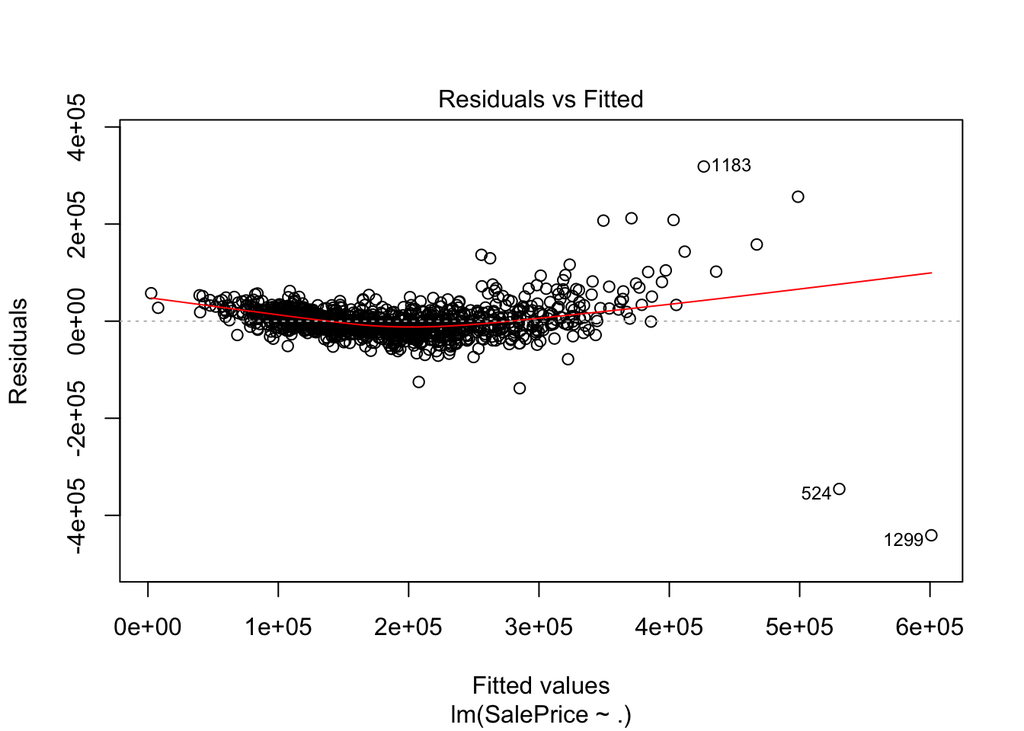

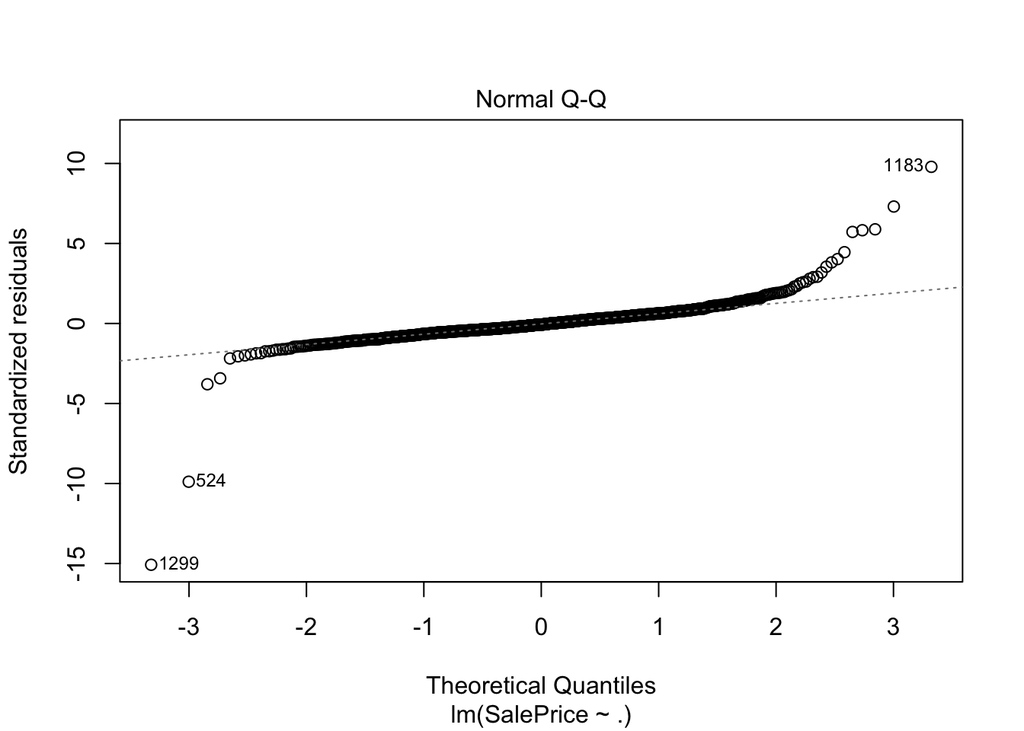

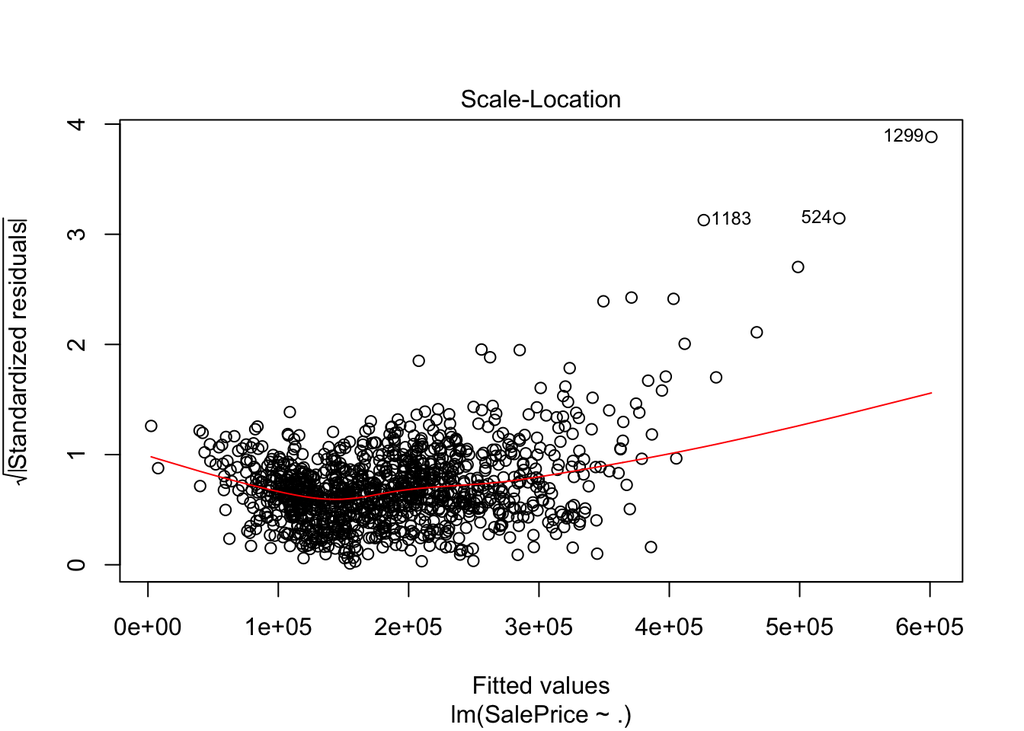

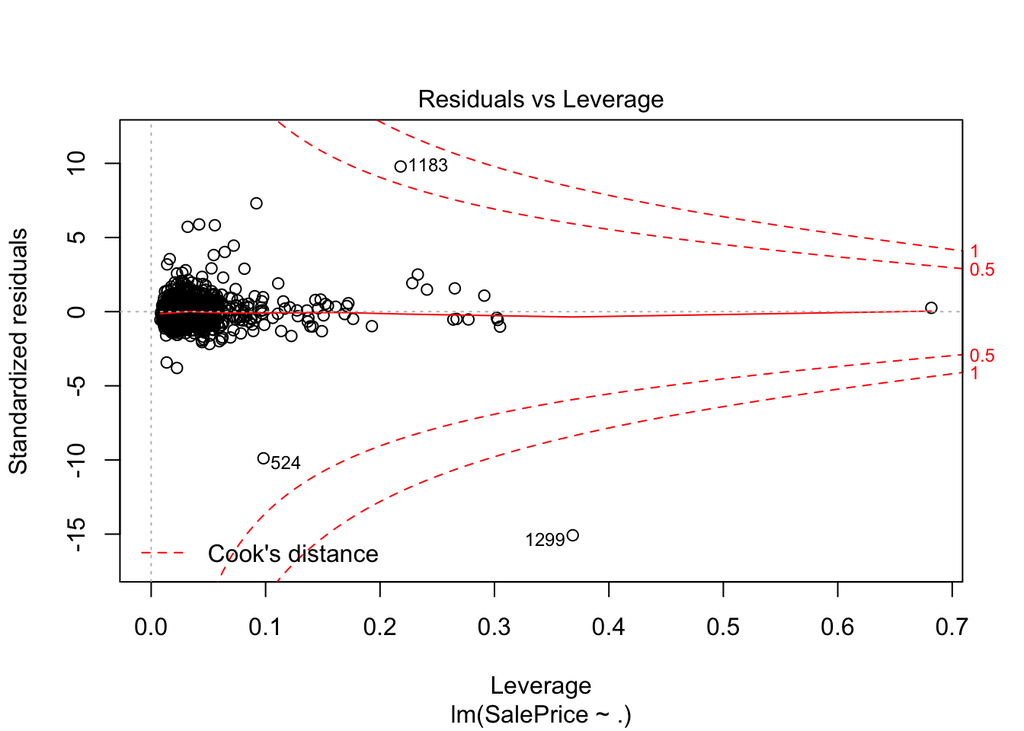

```r
plot(all)
```

# Problems with the Fit? Any Unusually High Leverages?

There are several large outliers;one observation has very high leverage, some others have moderately high leverage.

# Recall that the operator : designates the interaction between two variables. The operator * designates the interaction between the two variables, plus the main effects.

## Find Statistically Significant Interactions

```r
inter1<-lm(SalePrice~GrLivArea*FullBath,data=ameslist)
summary(inter1)
```

```
##
## Call:
## lm(formula = SalePrice ~ GrLivArea * FullBath, data = ameslist)
##
## Residuals:
##     Min      1Q  Median      3Q     Max
## -405547  -26243   -1872   20913  343810
##
## Coefficients:
##                     Estimate Std. Error t value Pr(>|t|)
## (Intercept)        38613.215  11906.700   3.243  0.00121 **
## GrLivArea             62.712      8.847   7.089  2.1e-12 ***
## FullBath            7270.139   7018.848   1.036  0.30047
## GrLivArea:FullBath    14.053      4.326   3.248  0.00119 **
## ---
## Signif. codes:  0 '***' 0.001 '**' 0.01 '*' 0.05 '.' 0.1 ' ' 1
##
## Residual standard error: 54680 on 1456 degrees of freedom
## Multiple R-squared:  0.5272, Adjusted R-squared:  0.5262
## F-statistic: 541.2 on 3 and 1456 DF,  p-value: < 2.2e-16
```

```r
inter2<-lm(SalePrice~LotFrontage:LotArea,data=ameslist)
summary(inter2)
```

```
##
## Call:
## lm(formula = SalePrice ~ LotFrontage:LotArea, data = ameslist)
##
## Residuals:
##     Min      1Q  Median      3Q     Max
## -342721  -50310  -20140   32035  549760
##
## Coefficients:
##                      Estimate Std. Error t value Pr(>|t|)
## (Intercept)         1.677e+05  2.779e+03  60.354   <2e-16 ***
## LotFrontage:LotArea 1.675e-02  1.934e-03   8.664   <2e-16 ***
## ---
## Signif. codes:  0 '***' 0.001 '**' 0.01 '*' 0.05 '.' 0.1 ' ' 1
##
## Residual standard error: 80930 on 1199 degrees of freedom
##   (259 observations deleted due to missingness)
## Multiple R-squared:  0.05892,    Adjusted R-squared:  0.05814
## F-statistic: 75.07 on 1 and 1199 DF,  p-value: < 2.2e-16
```

## Transformations of the Variables

# Baseline

```r
baseline <- lm(SalePrice ~ LotArea,data=ameslist)
summary(baseline)
```

```
##
## Call:
## lm(formula = SalePrice ~ LotArea, data = ameslist)
##
## Residuals:
##     Min      1Q  Median      3Q     Max
## -275668  -48169  -17725   31248  553356
##
## Coefficients:
##              Estimate Std. Error t value Pr(>|t|)
## (Intercept) 1.588e+05  2.915e+03   54.49   <2e-16 ***
## LotArea     2.100e+00  2.011e-01   10.45   <2e-16 ***
## ---
## Signif. codes:  0 '***' 0.001 '**' 0.01 '*' 0.05 '.' 0.1 ' ' 1
##
## Residual standard error: 76650 on 1458 degrees of freedom
## Multiple R-squared:  0.06961,    Adjusted R-squared:  0.06898
## F-statistic: 109.1 on 1 and 1458 DF,  p-value: < 2.2e-16
```

# Ln Transformation

The t value improved from 10 to 16 when using an ln function and the r^2 also got much better, going from 0.07 to 0.15.

```r
trans_ln <- lm(SalePrice ~ log(LotArea),data=ameslist)
summary(trans_ln)
```

```
##
## Call:
## lm(formula = SalePrice ~ log(LotArea), data = ameslist)
##
## Residuals:
##     Min      1Q  Median      3Q     Max
## -145261  -47995  -16602   34118  531531
##
## Coefficients:
##              Estimate Std. Error t value Pr(>|t|)
## (Intercept)   -362527      33809  -10.72   <2e-16 ***
## log(LotArea)    59648       3705   16.10   <2e-16 ***
## ---
## Signif. codes:  0 '***' 0.001 '**' 0.01 '*' 0.05 '.' 0.1 ' ' 1
##
## Residual standard error: 73230 on 1458 degrees of freedom
## Multiple R-squared:  0.1509, Adjusted R-squared:  0.1504
## F-statistic: 259.2 on 1 and 1458 DF,  p-value: < 2.2e-16
```

```r
summary(baseline)
```

```
##
## Call:
## lm(formula = SalePrice ~ LotArea, data = ameslist)
##
## Residuals:
##     Min      1Q  Median      3Q     Max
## -275668  -48169  -17725   31248  553356
##
## Coefficients:
##              Estimate Std. Error t value Pr(>|t|)
## (Intercept) 1.588e+05  2.915e+03   54.49   <2e-16 ***
## LotArea     2.100e+00  2.011e-01   10.45   <2e-16 ***
## ---
## Signif. codes:  0 '***' 0.001 '**' 0.01 '*' 0.05 '.' 0.1 ' ' 1
##
## Residual standard error: 76650 on 1458 degrees of freedom
## Multiple R-squared:  0.06961,    Adjusted R-squared:  0.06898
## F-statistic: 109.1 on 1 and 1458 DF,  p-value: < 2.2e-16
```

# Squared Transformation

There is no difference in result when the value is squared

```r
trans_x2 <- lm(SalePrice ~ (LotArea*LotArea),data=ameslist)
summary(trans_x2)
```

```
##
## Call:
## lm(formula = SalePrice ~ (LotArea * LotArea), data = ameslist)
##
## Residuals:
##     Min      1Q  Median      3Q     Max
## -275668  -48169  -17725   31248  553356
##
## Coefficients:
##              Estimate Std. Error t value Pr(>|t|)
## (Intercept) 1.588e+05  2.915e+03   54.49   <2e-16 ***
## LotArea     2.100e+00  2.011e-01   10.45   <2e-16 ***
## ---
## Signif. codes:  0 '***' 0.001 '**' 0.01 '*' 0.05 '.' 0.1 ' ' 1
##
## Residual standard error: 76650 on 1458 degrees of freedom
## Multiple R-squared:  0.06961,    Adjusted R-squared:  0.06898
## F-statistic: 109.1 on 1 and 1458 DF,  p-value: < 2.2e-16
```

```r
summary(baseline)
```

```
##
## Call:
## lm(formula = SalePrice ~ LotArea, data = ameslist)
##
## Residuals:
##     Min      1Q  Median      3Q     Max
## -275668  -48169  -17725   31248  553356
##
## Coefficients:
##              Estimate Std. Error t value Pr(>|t|)
## (Intercept) 1.588e+05  2.915e+03   54.49   <2e-16 ***
## LotArea     2.100e+00  2.011e-01   10.45   <2e-16 ***
## ---
## Signif. codes:  0 '***' 0.001 '**' 0.01 '*' 0.05 '.' 0.1 ' ' 1
##
## Residual standard error: 76650 on 1458 degrees of freedom
## Multiple R-squared:  0.06961,    Adjusted R-squared:  0.06898
## F-statistic: 109.1 on 1 and 1458 DF,  p-value: < 2.2e-16
```

# Sqrt Transformation

Using the squareroot, the r^2 value got better, going from .07 to .14 and the t value also improved from 10 to 15.

```r
trans_sqrt <- lm(SalePrice ~ sqrt(LotArea),data=ameslist)
summary(trans_sqrt)
```

```
##
## Call:
## lm(formula = SalePrice ~ sqrt(LotArea), data = ameslist)
##
## Residuals:
##     Min      1Q  Median      3Q     Max
## -263407  -46335  -16276   32787  537176
##
## Coefficients:
##               Estimate Std. Error t value Pr(>|t|)
## (Intercept)   81166.31    6905.23   11.75   <2e-16 ***
## sqrt(LotArea)  1013.33      67.33   15.05   <2e-16 ***
## ---
## Signif. codes:  0 '***' 0.001 '**' 0.01 '*' 0.05 '.' 0.1 ' ' 1
##
## Residual standard error: 73930 on 1458 degrees of freedom
## Multiple R-squared:  0.1345, Adjusted R-squared:  0.1339
## F-statistic: 226.5 on 1 and 1458 DF,  p-value: < 2.2e-16
```

```r
summary(baseline)
```

```
##
## Call:
## lm(formula = SalePrice ~ LotArea, data = ameslist)
##
## Residuals:
##     Min      1Q  Median      3Q     Max
## -275668  -48169  -17725   31248  553356
##
## Coefficients:
##              Estimate Std. Error t value Pr(>|t|)
## (Intercept) 1.588e+05  2.915e+03   54.49   <2e-16 ***
## LotArea     2.100e+00  2.011e-01   10.45   <2e-16 ***
## ---
## Signif. codes:  0 '***' 0.001 '**' 0.01 '*' 0.05 '.' 0.1 ' ' 1
##
## Residual standard error: 76650 on 1458 degrees of freedom
## Multiple R-squared:  0.06961,    Adjusted R-squared:  0.06898
## F-statistic: 109.1 on 1 and 1458 DF,  p-value: < 2.2e-16
```